# quarto-input82fd16edfdd89978

## Proyecto FIPA 2023-27

Diseño e implementación de estrategias de manejo utilizando plataforma [openMSE](https://openmse.com/) en la pesquería de jurel

Modelos operativos y procedimiento de manejo empírico

Fernando Espíndola

Instituto de Fomento Pesquero

## Tabla de contenidos

- Desarrollo de modelos operativos.
- Modelo operativo base y alternativos.
- Supuestos de la dinámica de los modelos operativos.
- Desarrollo de la regla de control de captura (RCC).
- Configuración de la RCC.
- Implementación procedimiento manejo (PM) basado regla empírica.
- Configuración del PM empírico.
- Simulación del procedimiento de manejo basado en regla empírica.
- Conclusiones.

## Modelos operativos

- Se desarrollaron MO que consideran las 4 flotas y 7 índices de abundancia.
- Durante el taller presencial (Dra. Robyn Forrest) se propusieron 3 MO.
- Estos se diferencian según los niveles de productividad en el periodo proyectado.
- Seleccionaron tres niveles de reclutamientos, alta, baja e histórico.
- Estos consideran su reclutamiento medio, desviación estándar y autocorrelación.
- De acuerdo a lo anterior, en la **Table 1** se muestra el detalle de los MO.

## Modelos operativos

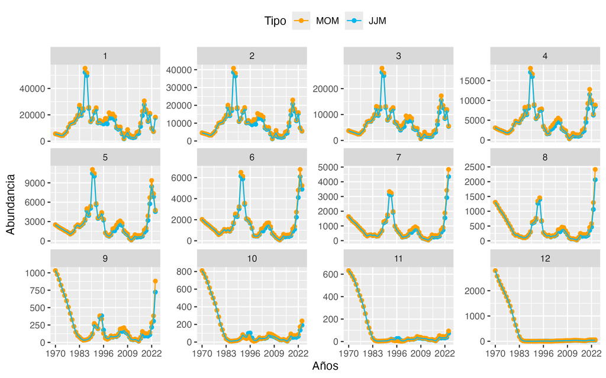

**Figura 1**: Comparación entre la abundancia por grupo de edad para el modelo operativo base y la abundancia estimada por el modelo de evaluación del stock de jurel (JJM)

## Modelos operativos

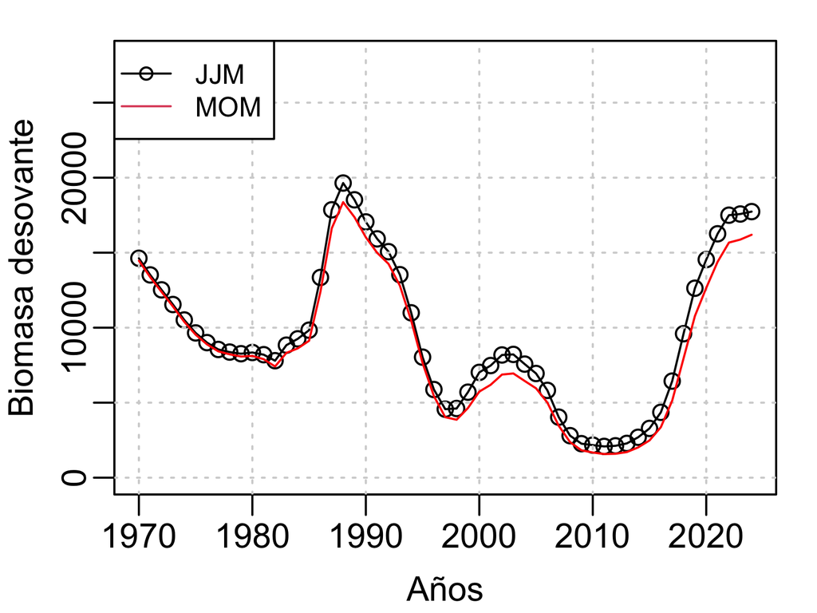

**Figura 2**: Comparación entre la biomasa desovante para el modelo operativo base y la biomasa desovante estimada por el modelo de evaluación del stock de jurel (JJM)

## Supuestos de la dinámica de los MO

- Error de proceso del reclutamiento: se consideró modelar cohortes de mayor tamaño en comparación con la media del periodo histórico, como también de menor tamaño. Definido como la desviación estándar de las desviaciones del reclutamiento en el espacio logarítmico, con el nivel de autocorrelación con retraso de menos uno.
- Parámetros de historia de vida: se consideró la ojiva de madurez, los pesos a la edad y M igual a 0,28 años<sup>-1</sup>.
- Selectividad: se considera la selectividad para cada una de las flotas al último año estimada por el modelo de evaluación mediante una camina aleatoria durante la proyección.
- Error de implementación: se acordó no incluir error de implementación para todos los procedimientos de manejo.
- Error de observación: es tomado de los residuales para los datos de captura de las 4 flotas y 7 índices de abundancia. Y se consideraron los tamños muestrales de 100 para representar el nivel de muestreo de las composiciones de edades en las capturas de las 4 flotas y de los índices de abundancia de los cruceros.

## Modelos operativos

Table 1: Resumen de los modelos operativos identificados para la EEM de jurel. Las descripciones se deben entender como variaciones del modelo operativo base con 4 flotas y 7 índices de abundancia (MO1).

| Identificador | Descripción |
| --- | --- |
| MO1 | Condicionado con el actual modelo de evaluación base del stock de jurel. Se consideran los reclutamientos históricos desdde 1970 al 2024 |
| MO2 | Igual al MO1, pero con un nivel bajo de reclutamientos durante el periodo de proyección, considerando el periodo desde 2003 hasta 2016 |
| MO3 | Igual al MO1, pero con un nivel alto de reclutamientos durante el periodo de proyección, considerando el periodo desde 1985 hasta 2001 |

## Modelos operativos

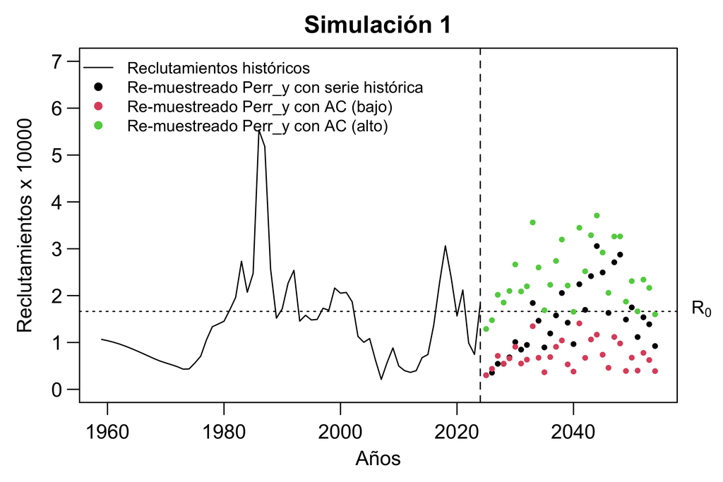

**Figura 3**: Reclutamiento para el periodo histórico y el de la proyección mostrando el comportamiento bajo las diferentes suposiciones, periodo histórico (puntos negros), reclutamientos bajos (puntos rojos) y reclutameintos altos (puntos verdes)

## Procedimiento de manejo (PM)

- El procedimiento de manejo (PM) o estrategia de manejo (EM) pesquero es un conjunto de reglas o algoritmos matemáticos que convierten los datos pesqueros en recomendaciones de manejo.
- El objetivo de la Evaluación de Estrategia de Manejo (EEM) es evaluar el desempeño de un número acotado de PM a fin de identificar un PM robusto a la incertidumbre del sistema biológico pesquero.
- Para lo cual, es necesario identificar un núemro acotado de modelos operativos.

## Configuración de la RCC

```r
empirical_HCR2 <- function(I_y, Iref = Iref, Cref = Cref, Cmin = Cmin, Ilim = Ilim) {
  n <- length(I_y)
  cba <- vector("numeric", length = n)
  slope <- (Cref - Cmin)/(Iref - Ilim)
  for(i in 1:n){
    val <- I_y[i]
    if(val < Iref & val > Ilim){cba[i] <- slope * (val - Ilim) + Cmin}
    if(val <= Ilim){cba[i] <- Cmin}
    if(val >= Iref){cba[i] <- Cref}
  }
  return(cba)
}
```

## Regla de control de captura (RCC)

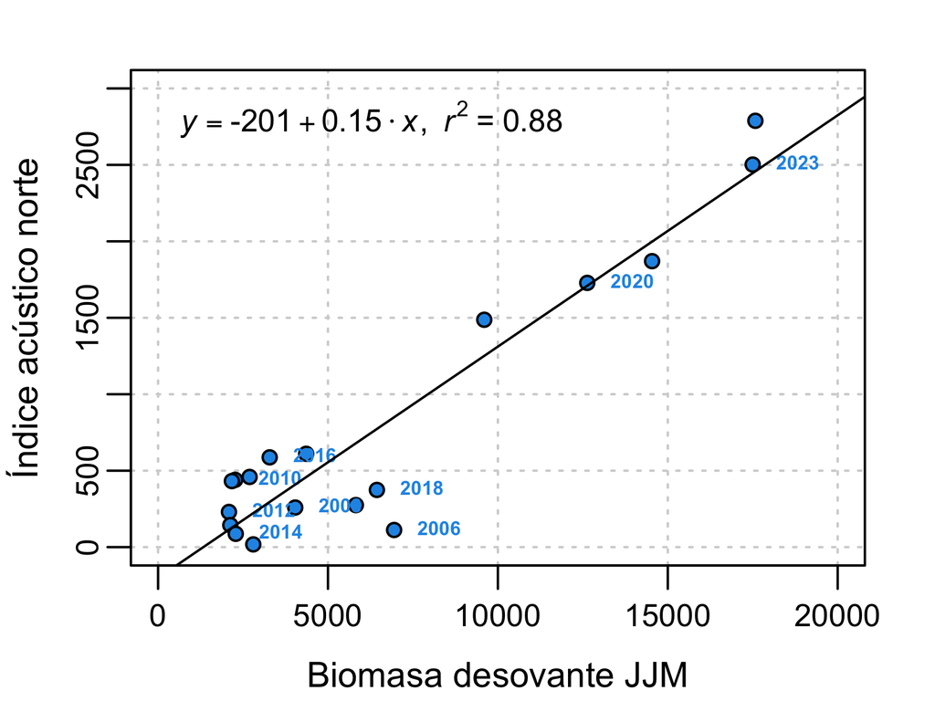

**Figura 4**: Relación entre la biomasa desovante estimada por el modelo de evaluación de stock y la biomasa total estimada por el crucero acústico de la zona norte de Chile. La serie de datos usada abarca desde el año 2000 hasta el presente. Se muestra la relación lineal entre las variables y el grado de ajuste.

## Regla de control de captura (RCC)

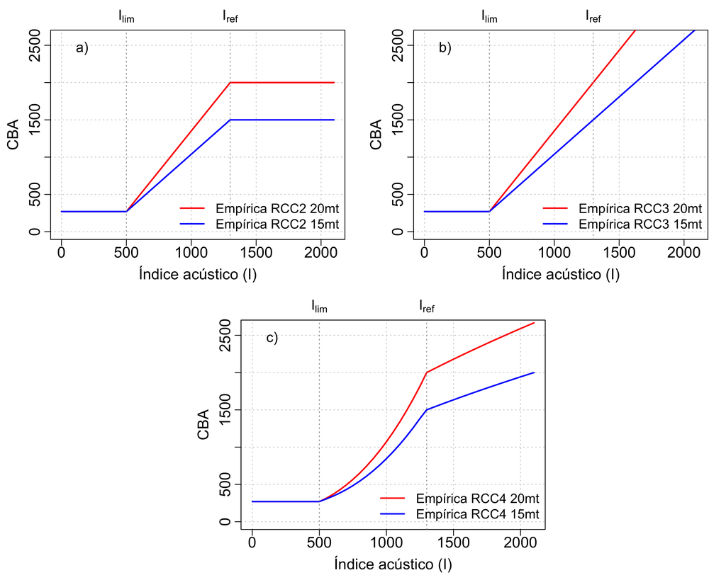

**Figura 5**: Relación entre la CBA y el índice de abundancia basado en el crucero acústico de la zona norte de Chile para tres formas funcionales de relación y dos niveles de captura de referencia (C<sub>ref</sub>) de 1,5 y 2,0 millones de toneladas.En el panel a) la RCC de tipo rampa, en b) la RCC de tipo lineal y en c) la RCC de tipo exponencial. El índice de referencia (I<sub>ref</sub>) fue fijado en 1,3 millones de toneladas y el índice límite (I<sub>lim</sub>) en 500 mil toneladas.

## Configuración del PM empírico

```r
Enmp_RRC2_15mt <- function(x, DataList, frac = c(0.0835,0.676,0.186,0.054), y_mean = 1,
                           Cmax = 1500, banda = c(0.2,0.1), data_lag = 1) {

  np <- length(DataList)
  nf <- length(DataLits[[1]])
  Data <- DataList[[1]][[1]]
  ny <- length(Data@Year)

  RecList <- lappy(1:np, function(p){
    lappy(1:nf,function(f){
       Rec <- new("Rec")
      Rec@TAC <- NA_real_
      return(Rec)
    })
  })

  if (max(Data@Year) == Data@LHYear) {
    CBA_previous <- 1200
  } else {
    CBA_previous <- as.numeric(Data@MPrec[x])
    for(f in 2:nf){
      CBA_previous <- CBA_previous + as.numeric(DataList[[1]][[f]]@MPrec[x])
    }
  }

  yind <- seq(ny - y_mean + 1, ny) - data_lag
  Ind <- Data@AddInd[x, 1, yind]

  CBA_now <- empirical_HCR2(Ind,Cmin=270,Cref=CBA_max,Ilim=500,Iref=1300)

  if (CBA_now/CBA_previous > 1+banda[1]) {CBA_now <- CBA_previous*(1+banda[1])}
  if (CBA_now/CBA_previous < 1-banda[2]) {CBA_now <- CBA_previous*(1-banda[2])}

  for (f in 1:nf) {RecList[[1]][[f]]@TAC <- frac[f] * CBA_now}

  return(RecList)
}
```

## Resumen de los PM empíricos

Table 2: Resumen de los procedimientos de manejo empíricos candidatos usados en la simulación.

| Nombre | Descripción |
| --- | --- |
| Emp_RCC2_15mt | Regla de control de captura de tipo rampa con un nivel de referencia de 1,5 millones de toneladas. |
| Emp_RCC2_20mt | Regla de control de captura de tipo rampa con un nivel de referencia de 2,0 millones de toneladas. |
| Emp_RCC3_15mt | Regla de control de captura de tipo lineal pasando por el nivel de referencia de 1,5 millones de toneladas. |
| Emp_RCC3_20mt | Regla de control de captura de tipo lineal pasando por el nivel de referencia de 2,0 millones de toneladas. |
| Emp_RCC4_15mt | Regla de control de captura de tipo exponencial con un cambio de forma en el nivel de referencia de 1,5 millones de toneladas. |
| Emp_RCC4_20mt | Regla de control de captura de tipo exponencial con un cambio de forma en el nivel de referencia de 2,0 millones de toneladas. |

## Simulación de los PM empíricos

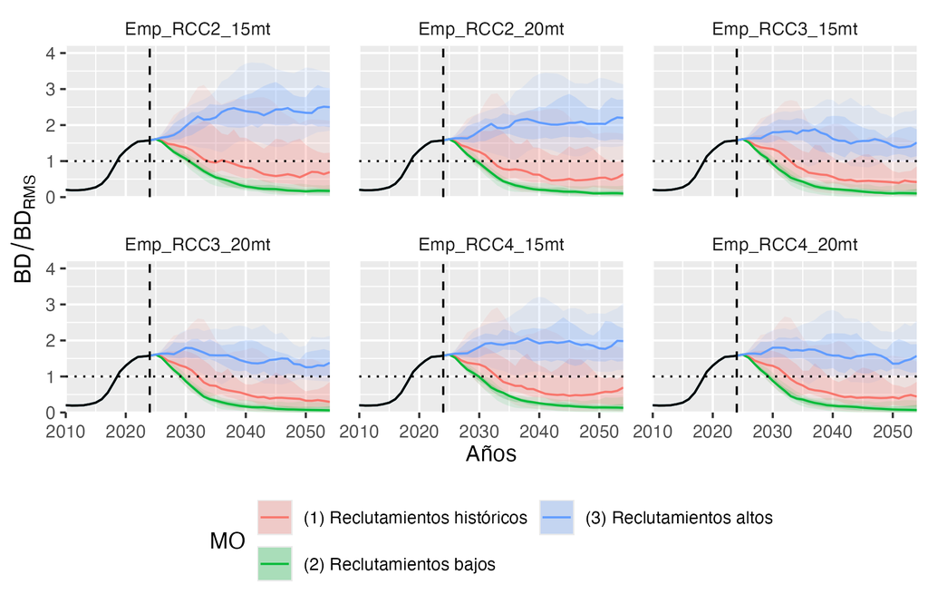

**Figura 6**: Series de la razón de la biomasa desovante (BD) respecto de la biomasa desovante en el rendimiento máximo sostenible (BD<sub>RMS</sub>) para cada modelo operativo (colores) y los diferentes procedimiento de manejo empíricos. Las líneas corresponden a la mediana y las bandas de color corresponden al cuantil del 95% a través de todas las simulaciones. El período histórico (previo al 2024) está indicado por la línea vertical segmentada negra. La línea horizontal punteada corresponde a la BD<sub>RMS</sub>.

## Simulación de los PM empíricos

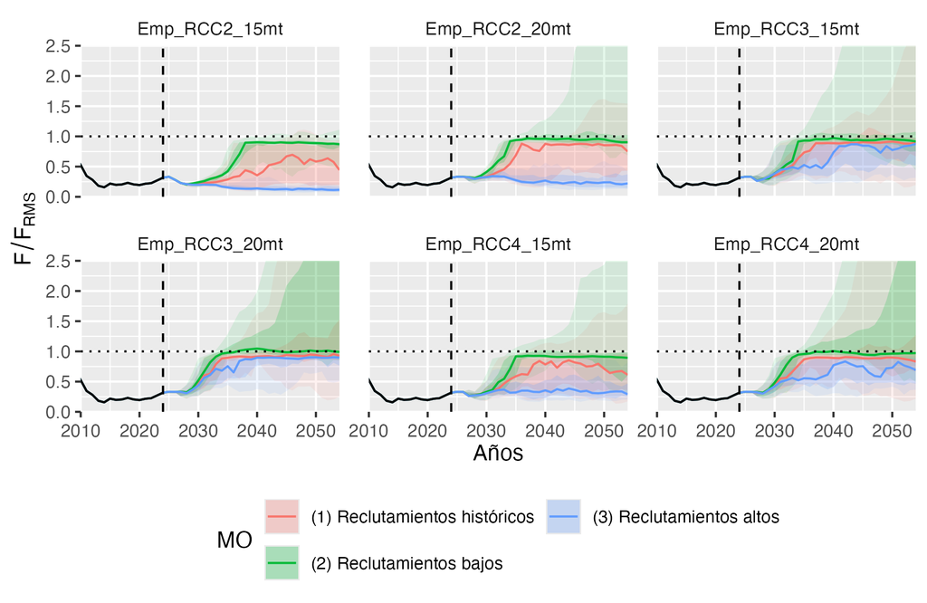

**Figura 7**: Series de la razón de la mortalidad por pesca (F) respecto de la mortalidad por pesca en el rendimiento máximo sostenible (F<sub>RMS</sub>) para cada modelo operativo (colores) y los diferentes procedimiento de manejo empíricos. Las líneas corresponden a la mediana y las bandas de color corresponden al cuantil del 95% a través de todas las simulaciones. El período histórico (previo al 2024) está indicado por la línea vertical segmentada negra. La línea horizontal punteada corresponde a la F<sub>RMS</sub>.

## Simulación de los PM empíricos

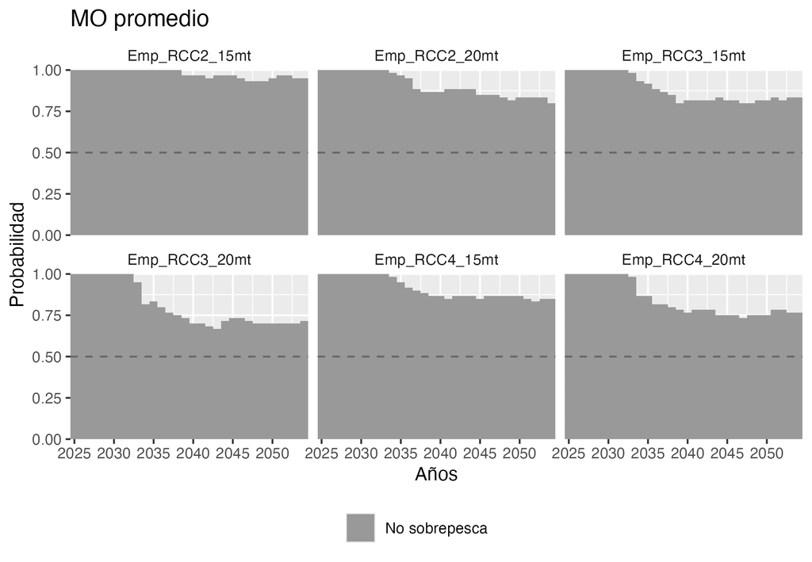

**Figura 8**: Probabilidad de no sobrepesca de acuerdo con al diagrama de fase o Kobe plot temporal, con la proporción de las simulaciones en donde la mortalidad por pesca de jurel se encontró por debajo de F<sub>RMS</sub> para cada año de la proyección y procedimiento de manejo. Valores medios a través de todos los modelos operativos.

## Simulación de los PM empíricos

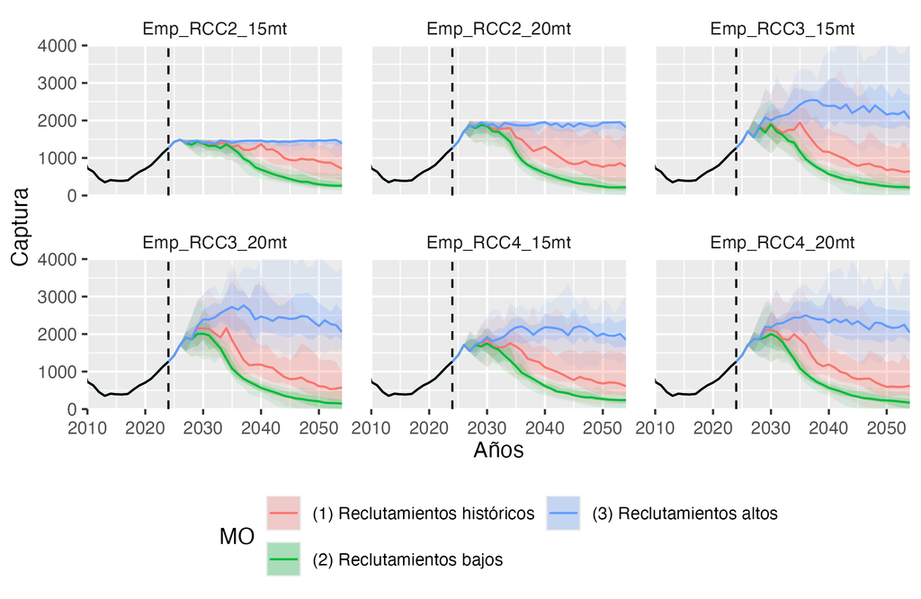

**Figura 9**: Series de captura en miles de toneladas por modelo operativo (colores) y procedimiento de manejo. Las líneas corresponden a la mediana y las bandas de color corresponden al cuantil del 95% a través de todas las simulaciones. El período histórico (previo al 2024) está indicado por la línea vertical segmentada negra.

## Simulación de los PM empíricos

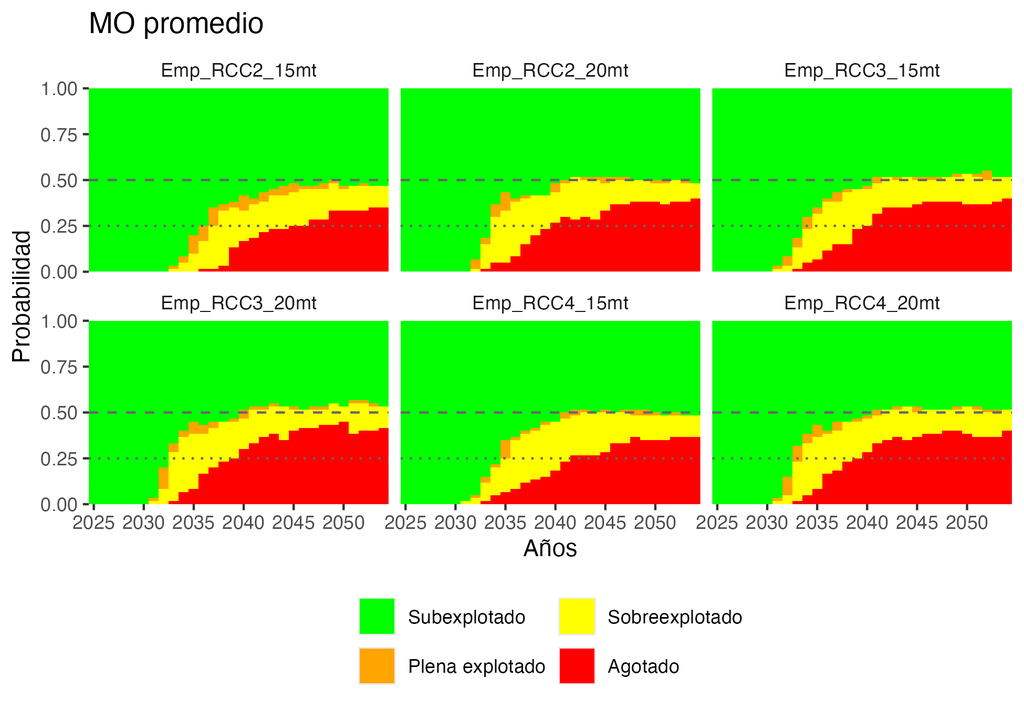

**Figura 10**: Diagrama de fase o Kobe plot temporal con la proporción de las simulaciones de la condición del stock de jurel con respecto a su biomasa para cada año durante el periodo proyectado y para los diferentes PM. Las áreas coloreadas representan los valores medios para todos los modelos operativos. Las líneas horizontales segmentada y punteada representa el nivel de probabilidad de 0,5 y 0,25, respectivamente.

## Conclusiones

- Los resultados mostraron que el PM empírico RCC2 con una C<sub>ref</sub> de 1,5 millones de toneladas presenta un desempeño relativamente superior.
- Esto se debe a que incorpora un límite superior en la captura, con un valor de referencia menor.
- En general, la C<sub>ref</sub> de 1,5 millones de toneladas condiciona con rendimiento bajo de los PM para los MO1 y MO2 durante el corto periodo proyectado de 30 años.
- Los niveles de captura recomendados por los PM empíricos en el corto plazo se traducen en disminuciones de la biomasa desovante para los MO1 y MO2.
- Esto podría estar vinciulado a la banda de estabilización, en que la captura no puede bajar más de un 10% de la captura del año anterior, manteniendo captura elevadas a un costo de disminuir la biomasa.
- El PM empírico RCC2 con una C<sub>ref</sub> de 1,5 millones de toneladas mostró una probabilidad levemente superior al 0,5 de estar en una condición de sub-explotación a través de todos los MO.

## Gracias por su atención

Nos vemos en IFOP